# Classifying NBA Player's Position from Game Stats using k-NN

```python
from IPython.display import HTML
HTML('''<script>
code_show=true;
function code_toggle() {
 if (code_show){
 $('div.input').hide();
 } else {
 $('div.input').show();
 }
 code_show = !code_show
}
$( document ).ready(code_toggle);
</script>
<form action="javascript:code_toggle()"><input type="submit" value="Click here to toggle on/off the raw code."></form>''')
```

## Strength in Numbers: Classifying NBA Player's Position from Game Stats using k-NN

By: MSDS2021 LT3 - Ang, Antioquia, Carpio, Dolorso, Patalud

## I. Problem: Can we determine an NBA player's position by their stats per game?

From the pre-2000s big man era full of post-ups, to fast-paced offense strategies like the Suns' *7-seconds or less*, and even until today's 3-point driven basketball, the game of basketball has evolved throughout the decades. And, along with it, is how each player's position is played.

In the past few years, pick-and-roll has become the cornerstone of NBA games. It is a type of offense that involves a lot of switching of defenders -- which then gave birth to *positionless basketball*, where each defender can switch to someone in offense regardless of position.

With today's games having an emphasis on switching and floor spacing, we want to know if we can still determine an NBA player's position by their stats using K-Nearest Neighbors (KNN) classifier.

## II. Highlights of the Results

- Players' positions can be identified based on their season average statistics.
- Accuracy improves when classifying positions as Frontcourt or Backcourt.
- Assists, defensive rebounds, and 3-pointers are the most important features.

## III. Data Discussion

Data for NBA games are openly available in [Basketball Reference](https://www.basketball-reference.com/).

This is where we sourced both the [per game](https://www.basketball-reference.com/leagues/NBA_2020_per_game.html) and [per 36 min](https://www.basketball-reference.com/leagues/NBA_2020_per_minute.html) stats for 2015-2020 NBA seasons that are used in this study.

The data contains stats for 1299 players. Players that were traded within a season have a separate average stats entry for each team they played for, resulting in a total of 6180 rows.

Both per game and per 36 min stats have the same columns:

- **`Season`**: Year of NBA season
- **`Rk`**: Rank alphabetically
- **`Player`**: Player name
- **`Pos`**: Position
- **`Age`**: Player's age on February 1 of the season
- **`Tm`**: Team
- **`G`**: Games
- **`GS`**: Games Started
- **`MP`**: Minutes Played *
- **`FG`**: Field Goals *
- **`FGA`**: Field Goal Attempts *
- **`FG%`**: Field Goal Percentage
- **`3P`**: 3-Point Field Goals *
- **`3PA`**: 3-Point Field Goal Attempts *
- **`3P%`**: 3-Point Field Goal Percentage
- **`2P`**: 2-Point Field Goals *
- **`2PA`**: 2-Point Field Goal Attempts *
- **`2P%`**: 2-Point Field Goal Percentage
- **`eFG%`**: Effective Field Goal Percentage **
- **`FT`**: Free Throws *
- **`FTA`**: Free Throw Attempts *
- **`FT%`**: Free Throw Percentage
- **`ORB`**: Offensive Rebounds *
- **`DRB`**: Defensive Rebounds *
- **`TRB`**: Total Rebounds *
- **`AST`**: Assists *
- **`STL`**: Steals *
- **`BLK`**: Blocks *
- **`TOV`**: Turnovers *
- **`PF`**: Personal Fouls *
- **`PTS`**: Points *

* - per game / per 36 min  
** - This statistic adjusts for the fact that a 3-point field goal is worth one more point than a 2-point field goal.

## IV. Data Preprocessing

### Import Packages

```python
from sklearn.neighbors import KNeighborsClassifier
import numpy as np
%matplotlib inline
import matplotlib.pyplot as plt
import pandas as pd
import plotly.graph_objects as go
from sklearn.model_selection import train_test_split
from sklearn.neighbors import KNeighborsClassifier
from sklearn.model_selection import cross_val_score
from sklearn.preprocessing import StandardScaler
from sklearn.preprocessing import MinMaxScaler
from sklearn.preprocessing import RobustScaler
from sklearn.metrics import accuracy_score
from sklearn.model_selection import train_test_split
from sklearn.metrics import roc_auc_score
from sklearn.model_selection import GridSearchCV
import warnings
warnings.filterwarnings('ignore')
from collections import Counter
```

### Preprocessing Assumptions

1. We only considered data from the 2015-2020 NBA seasons to capture more recent game trends.
2. We only considered players with more than 10 games played.
3. Rows with null values were dropped (this is only one row).
4. We dropped columns that are irrelevant, and those which were correlated:
   - **Irrelevant columns**: Season, Rank, Player, Games, Games Started
   - **Percentages**: this can be derived from made/attempts
   - **Total Rebounds**: this is the sum of ORB and DRB
   - **Total Points**: this is a function of 3P, 2P and FT
   - **Total Field Goals**: this is the sum of 3P and 2P
   - **All Attempts metrics**: this includes 2PA, 3PA, and FTA, which are closely related to the `Made` metrics such as 2P, 3P, and FT. We find higher accuracy in the model when retaining the `Made` metrics rather than the `Attempt` metrics.

```python
# Loading the dataset
df_nba = pd.read_excel('nba_stats_per_36mins_2010-2020.xlsx')

# Consider only the 2015-2020 seasons
seasons = ['2015-2016', '2016-2017', '2017-2018', '2018-2019', '2019-2020']
df_nba = df_nba[df_nba['Season'].isin(seasons)]

# Dropping Games Started column
df_nba.drop('GS', axis=1, inplace=True)

# Dropping players with less than 10 games played
df_nba.drop(df_nba[df_nba['G'] < 10].index, axis=0, inplace=True)

# Dropping the row with null
df_nba.dropna(inplace=True)

# Dropping percentage metrics
df_nba.drop(['FG%', '3P%', '2P%', 'FT%'], axis=1, inplace=True)

# Dropping total rebounds, points, field goals, and all attempts metrics
df_nba.drop(['TRB','PTS','FG','FGA','2PA','3PA','FTA'], axis=1, inplace=True)
```

## V. Setting Up the Features and Target Variables

### Final List of Features

- 3P, 2P, FT, ORB, DRB, AST, STL, BLK, TOV, PF

### Positions

- PG (Point Guard) - Target Variable: 0
- SG (Shooting Guard) - Target Variable: 1
- SF (Small Forward) - Target Variable: 2
- PF (Power Forward) - Target Variable: 3
- C (Center) - Target Variable: 4

### Frontcourt vs Backcourt

- Frontcourt (C, PF, and SF) - Target Variable: 0
- Backcourt (SG and PG) - Target Variable: 1

```python
# Adding target column for positions
pos = ['PG', 'SG', 'SF', 'PF', 'C']
df_nba.drop(df_nba[~df_nba['Pos'].isin(pos)].index, axis=0, inplace=True)
df_nba['Target'] = [pos.index(player) for player in df_nba['Pos']]

# Adding target column for front court vs backcourt
df_nba['Target2'] = [1 if target < 2 else 0 for target in df_nba['Target']]

# Splitting data and target dataset
df_features = df_nba.iloc[:,8:-2]
df_target = df_nba['Target']
data = df_features.to_numpy()
target = df_target.to_numpy()

print(f"Shape of data: {data.shape}")
print(f"Shape of target: {target.shape}")
```

```
Shape of data: (2548, 10)
Shape of target: (2548,)
```

```python
df_features.head()
```

|  | 3P | 2P | FT | ORB | DRB | AST | STL | BLK | TOV | PF |
| --- | --- | --- | --- | --- | --- | --- | --- | --- | --- | --- |
| 0 | 0.0 | 6.0 | 2.5 | 4.5 | 8.0 | 3.2 | 1.2 | 1.5 | 2.0 | 2.6 |
| 1 | 0.0 | 6.6 | 3.8 | 2.7 | 8.3 | 5.4 | 1.3 | 1.4 | 3.0 | 2.6 |
| 2 | 1.3 | 6.8 | 3.2 | 2.1 | 5.9 | 2.6 | 0.7 | 1.8 | 1.5 | 2.6 |
| 3 | 2.9 | 2.7 | 1.2 | 0.6 | 5.2 | 5.3 | 0.8 | 0.5 | 2.9 | 3.3 |
| 4 | 2.4 | 3.3 | 2.2 | 0.4 | 4.4 | 3.1 | 0.4 | 0.1 | 1.7 | 2.6 |

```python
df_target.head()
```

```
0    4
1    3
2    4
3    1
4    1
Name: Target, dtype: int64
```

## VI. Key Considerations in k-NN Implementation

### Applying min-max scaling to NBA stats

Game stats generally do not have the same magnitude. Points, rebounds, and assists are usually greater in quantity than steals and blocks. On the other hand, personal fouls are only limited to 6 per player for every game.

Since KNN weighs all features evenly, it is apparent how scaling helps improve the accuracy especially for these kinds of data. **For all our analyses, we use min-max scaling to standardize the units.**

### Per 36-min vs Per-game Stats

Per-36 min is more of an efficiency measure that extrapolates the production of a player into 36 minutes of play. this means that if a player had 3 rebounds for 9 minutes of game time, it would equate to 12 rebounds per 36 min.

A player who played for 40 minutes would have higher stats than someone who only played for 10 minutes. The per-36 min metric makes all the stats comparable, which is why NBA analysts prefer this measure than per-game averages, especially when comparing bench players to starters.

We adopted this same reasoning for our analysis to determine our dataset.

### Determining Frontcourt/Backcourt is more reliable than specific positions

Based on the results, using k-NN can predict specific player positions with decent accuracy (66.03%), but it is easier and more reliable to determine if a player is on Frontcourt or Backcourt (86.56%).

This can be attributed to the current trend of NBA games where the line between positions are thinner due to focus on [pick-and-roll offense](https://www.breakthroughbasketball.com/fundamentals/pick-and-roll.html) and constant switching on defense. There's also a lot of [stretch 4s and strech 5s](https://www.theringer.com/2017/5/10/16077348/2017-nba-playoffs-al-horford-boston-celtics-rise-of-stretch-5-68cc1067e83f) who are Power Forward or Center, but also shoot 3-pointers well, improving the floor spacing for the team.

## VII. Model Results

### Creating an Accuracy Function for Evaluating k-NN Models

We created a function below to help us evaluate the accuracy of k-NN models over a given number of trials and different `k`-neighbor settings.

We will use this function across all scenarios that we will run.

```python
def accuracy_per_neighbors(data, target, neighbors=50, trials=100,
                           lines=0, show_graph=True, title='',
                           test_size=0.25, metric='minkowski'):
    """
    Accepts data, target, number of neighbors, trials, lines, and show_graph.

    Creates a dataframe with the following columns:
    - Neighbors
    - Training accuracy mean
    - Training accuracy standard deviation
    - Test accuracy mean
    - Test accuracy standard deviation

    lines - determines the number of lines to display (default: 0 lines)

    If `graph` is True, displays a plotly graph of training and test accuracy
    per neighbor n with standard deviation as the y_error.
    """

    n_neighbors = [x for x in range(1,neighbors+1)]
    train_mean = []
    test_mean = []
    train_std = []
    test_std = []

    for n_neighbor in n_neighbors:
        training_accuracy = []
        test_accuracy = []

        for state in range(trials):
            X_train, X_test, y_train, y_test = train_test_split(
                data, target, test_size=test_size,
                random_state=state)

            clf = KNeighborsClassifier(n_neighbors=n_neighbor, metric=metric)
            clf.fit(X_train, y_train)
            # record training set accuracy
            training_accuracy.append(clf.score(X_train, y_train))
            # record generalization accuracy
            test_accuracy.append(clf.score(X_test, y_test))

        train_mean.append(np.mean(training_accuracy))
        test_mean.append(np.mean(test_accuracy))
        train_std.append(np.std(training_accuracy))
        test_std.append(np.std(test_accuracy))

    df = pd.DataFrame({'neighbors':n_neighbors, 'train_mean':train_mean,
                       'test_mean':test_mean, 'train_std':train_std,
                       'test_std':test_std})

    print('Neighbors: {}'.format(neighbors))
    print('Trials: {} \n'.format(trials))
    print(f'Max accuracy at {round(max(test_mean), 4)} '
          f'when k={test_mean.index(max(test_mean)) + 1}\n')

    if lines:
        print('First {} lines: \n {}'.format(lines, df.head(lines)))

    if show_graph == True:
        fig = go.Figure(data=[
        go.Scatter(
            name='Testing Accuracy',
            mode='lines+markers',
            x=df['neighbors'],
            y=df['test_mean'],
            error_y=dict(
                type='data',
                array=df['test_std'],
                visible=True, thickness=.7),
            ),
        go.Scatter(
            name='Training Accuracy',
            mode='lines+markers',
            x=df['neighbors'],
            y=df['train_mean'],
            error_y=dict(
                type='data',
                array=df['train_std'],
                visible=True, thickness=.7),
        )])
        fig.update_layout(legend_orientation="h", legend=dict(x=0.65, y=1.1),
                        xaxis_title='# of Neighbors',
                        yaxis_title='Accuracy (mean and std dev)',
                        title={
                        'text': title,
                        'y':0.85,
                        'x':0.1,
                        'xanchor': 'left',
                        'yanchor': 'top'})

        fig.show()
```

## Highlight 1: Players' positions can be identified based on their season average statistics.

Max test accuracy is achieved at **66.03% when k=7**. This can still be considered a successful Classifier model, given that test accuracy significantly exceeded the 1.25PCC threshold of **25.54%**.

```python
# Create copy of features
data_minmax = df_features.copy()

# Choose scaler
scaler = MinMaxScaler()

for col in data_minmax.columns:
    data_minmax[col] = scaler.fit_transform(
        data_minmax[col].values.reshape(1,-1).T)

accuracy_per_neighbors(data_minmax, target,
                       title='NBA Positions - Min Max Scaling')
```

```
Neighbors: 50
Trials: 100

Max accuracy at 0.6603 when k=7
```

[interactive chart not shown]

### Comparing to PCC

Test accuracy scores are all higher than 1.25PCC threshold of **25.54%**.

```
Population per class:      0
4  389
3  529
1  616
2  479
0  535

Proportion Chance Criterion: 20.42855664183316%
1.25 * Proportion Chance Criterion: 25.535695802291453%
```

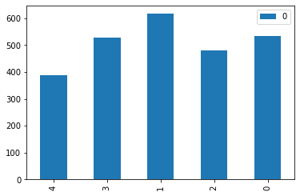

```python
state_counts = Counter(df_nba['Target'].to_numpy())
df_state = pd.DataFrame.from_dict(state_counts, orient='index')
df_state.plot(kind='bar')

num=(df_state[0]/df_state[0].sum())**2
print("Population per class: {}\n".format(df_state))
print("Proportion Chance Criterion: {}%".format(100*num.sum()))
print("1.25 * Proportion Chance Criterion: {}%".format(1.25*100*num.sum()))
```

## Highlight 2: Accuracy further improves when classifying players as Frontcourt/Backcourt

Max test accuracy is achieved at **86.56% when k=3**. This is a successful Classifier model given that test accuracy significantly exceeded the 1.25PCC threshold of **63.08%**.

```python
# Redefining the data and target variables
df_features = df_nba.iloc[:,8:-2]
df_target = df_nba['Target2']
data = df_features.to_numpy()
target = df_target.to_numpy()

# Create copy of features
data_minmax = df_features.copy()

# Choose scaler
scaler = MinMaxScaler()

for col in data_minmax.columns:
    data_minmax[col] = scaler.fit_transform(
        data_minmax[col].values.reshape(1,-1).T)

accuracy_per_neighbors(data_minmax, target,
                       title='NBA Positions - Min Max Scaling')
```

```
Neighbors: 50
Trials: 100

Max accuracy at 0.8656 when k=3
```

[interactive chart not shown]

### Comparing to PCC

Test accuracy scores are all higher than 1.25PCC threshold of **63.08%**.

```
Population per class:       0
0  1397
1  1151

Proportion Chance Criterion: 50.46605950676369%
1.25 * Proportion Chance Criterion: 63.08257438345462%
```

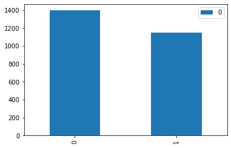

```python
state_counts = Counter(df_nba['Target2'].to_numpy())
df_state = pd.DataFrame.from_dict(state_counts, orient='index')
df_state.plot(kind='bar')

num=(df_state[0]/df_state[0].sum())**2
print("Population per class: {}\n".format(df_state))
print("Proportion Chance Criterion: {}%".format(100*num.sum()))
print("1.25 * Proportion Chance Criterion: {}%".format(1.25*100*num.sum()))
```

The most important features are **Assists (AST), Defensive Rebounds (DRB), and 3-pointers (3P)**. Based on the table below, these are the features that will cause the highest accuracy dip to the model when removed. This conclusion is consistent whether we are classifying based on player position or frontcourt v. backcourt.

### Important Features for Classifying Player Positions

```python
# Check score per removed feature
clf = KNeighborsClassifier()
features_copy = df_features.copy()
y =  df_nba['Target'].to_numpy()
number_features = features_copy.shape[1]

result = {}
for i in range(number_features):
    name = features_copy.iloc[:,i].name
    X_head = np.atleast_2d(features_copy.iloc[:, 0:i])
    X_tail = np.atleast_2d(features_copy.iloc[:, i+1:])
    X = np.hstack((X_head, X_tail))
    scores = cross_val_score(clf, X, y, cv=3)
    result[name] = scores.mean()

df_scores = pd.DataFrame.from_dict(
    result,orient='index').rename(columns={0:'Score'}).sort_values(
    'Score', ascending=False)
df_scores
```

|  | Score |
| --- | --- |
| 2P | 0.642866 |
| FT | 0.636586 |
| TOV | 0.631088 |
| ORB | 0.627169 |
| BLK | 0.625598 |
| STL | 0.623639 |
| PF | 0.623244 |
| 3P | 0.618536 |
| DRB | 0.582818 |
| AST | 0.563197 |

### Important Features for Classifying Frontcourt vs Backcourt

```python
# Check score per removed feature
clf = KNeighborsClassifier()
features_copy = df_features.copy()
y =  df_nba['Target2'].to_numpy()
number_features = features_copy.shape[1]

result = {}
for i in range(number_features):
    name = features_copy.iloc[:,i].name
    X_head = np.atleast_2d(features_copy.iloc[:, 0:i])
    X_tail = np.atleast_2d(features_copy.iloc[:, i+1:])
    X = np.hstack((X_head, X_tail))
    scores = cross_val_score(clf, X, y, cv=3)
    result[name] = scores.mean()

df_scores = pd.DataFrame.from_dict(
    result,orient='index').rename(columns={0:'Score'}).sort_values(
    'Score', ascending=False)
df_scores
```

|  | Score |
| --- | --- |
| 2P | 0.861462 |
| FT | 0.859113 |
| PF | 0.859110 |
| TOV | 0.859108 |
| STL | 0.856754 |
| BLK | 0.855970 |
| ORB | 0.851258 |
| 3P | 0.850865 |
| AST | 0.845372 |
| DRB | 0.818294 |

## VIII. Illustrating Results Using Per-Game Stats

### Re-running the data, and defining new features and target variables

```python
# Reloading the dataset
df_nba = pd.read_excel('per game stats 2010-2020.xlsx')

# Consider only the 2015-2020 seasons
seasons = ['2015-2016', '2016-2017', '2017-2018', '2018-2019', '2019-2020']
df_nba = df_nba[df_nba['Season'].isin(seasons)]

# Dropping Games Started column
df_nba.drop('GS', axis=1, inplace=True)

# Dropping players with less than 10 games played
df_nba.drop(df_nba[df_nba['G'] < 10].index, axis=0, inplace=True)

# Dropping the row with null
df_nba.dropna(inplace=True)

# Dropping percentage metrics
df_nba.drop(['FG%', '3P%', '2P%', 'FT%'], axis=1, inplace=True)

# Dropping total rebounds, points, field goals, and all attempts metrics
df_nba.drop(['TRB','PTS','FG','FGA','2PA','3PA','FTA'], axis=1, inplace=True)

# Adding target column for positions
pos = ['PG', 'SG', 'SF', 'PF', 'C']
df_nba.drop(df_nba[~df_nba['Pos'].isin(pos)].index, axis=0, inplace=True)
df_nba['Target'] = [pos.index(player) for player in df_nba['Pos']]

# Adding target column for front court vs backcourt
df_nba['Target2'] = [1 if target < 2 else 0 for target in df_nba['Target']]

# Splitting data and target dataset
df_features = df_nba.iloc[:,8:-2]
df_target = df_nba['Target']
data = df_features.to_numpy()
target = df_target.to_numpy()

print(f"Shape of data: {data.shape}")
print(f"Shape of target: {target.shape}")
```

```
Shape of data: (2548, 11)
Shape of target: (2548,)
```

### Results for Player Position Classification

Max test accuracy is achieved at **62.36% when k=15**. This can still be considered a successful Classifier model given that test accuracy significantly exceeded the 1.25PCC threshold of **25.54%**.

```python
# Redefining the data and target variables
df_features = df_nba.iloc[:,8:-2]
df_target = df_nba['Target']
data = df_features.to_numpy()
target = df_target.to_numpy()

# Create copy of features
data_minmax = df_features.copy()

# Choose scaler
scaler = MinMaxScaler()

for col in data_minmax.columns:
    data_minmax[col] = scaler.fit_transform(
        data_minmax[col].values.reshape(1,-1).T)

accuracy_per_neighbors(data_minmax, target,
                       title='NBA Positions - Min Max Scaling')
```

```
Neighbors: 50
Trials: 100

Max accuracy at 0.6236 when k=15
```

[interactive chart not shown]

```python
# Redefining the data and target variables
df_features = df_nba.iloc[:,8:-2]
df_target = df_nba['Target']
data = df_features.to_numpy()
target = df_target.to_numpy()

# Create copy of features
data_minmax = df_features.copy()

# Choose scaler
scaler = MinMaxScaler()

for col in data_minmax.columns:
    data_minmax[col] = scaler.fit_transform(
        data_minmax[col].values.reshape(1,-1).T)

accuracy_per_neighbors(data_minmax, target,
                       title='NBA Positions - Min Max Scaling')
```

```
Neighbors: 50
Trials: 100

Max accuracy at 0.6236 when k=15
```

[interactive chart not shown]

## IX. Conclusion

Players' positions can be identified based on their season average statistics, with relatively high accuracy of **66.03%** vs 1.25PCC threshold of **25.54%**. Meanwhile, accuracy further improves to **86.56%** vs 1.25PCC threshold of **63.08%** when classifying positions as Frontcourt or Backcourt. Based on our k-NN model results, we find that the key factors to classify player positions are Assists, Defensive Rebounds, and 3-pointers.

As was noted previously, the juxtaposition of the difficulty to categorize individual positions, against the more effective strategy of differentiating between frontcourt and backcourt players, can be attributed to the emergence of *positionless basketball*. Essentially, the lines between the roles of each position in the game are becoming increasingly blurred as each player is called on to contribute what they can -- to perform at full capability -- in order to secure that win. Still, the fairly strong distinction between the frontcourt and backcourt players show that each role has different strengths.

Drawing on the top three statistics that influence the Classification, it can be argued that the hallmark of a backcourt player is their ability to control the tempo and flow of the game (assists). In contrast, frontcourt players are characterised more by their flexibility to be where they are needed -- be it to catch that rebound, or sink that 3-pointer -- which improves the reach of the team.